# Sex biases brain volume estimates

# Small analysis for sex effects on brain volume estimates.

This datasets contains of real world dataset from an MRI study. Given are the variables SUBJECT_ID, AGE, SEX, HEAD_SIZE, BRAIN_VOLUME. HEAD_SIZE is equal to the head circumference in cm. BRAIN_VOLUME is the estimated volume by an MRI analysis software [FSL Sienax](https://fsl.fmrib.ox.ac.uk/fsl/fslwiki/SIENA).  
We start by read in the datafile and plot sex differences and associations of BRAIN_VOLUME with HEAD_SIZE. A strong association can be appreciated.

```r
rm(list=ls()) # Clear dataspace
library(tidyverse)
library(ggpubr)
# Read in data
my_data <-read_csv("Brain_Size.csv")
```

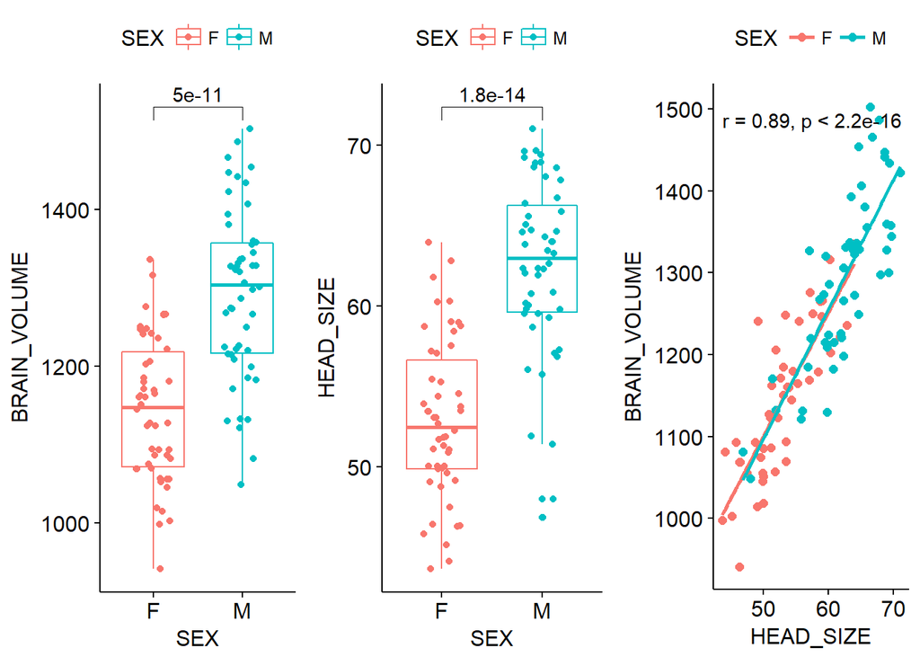

```r
# Specify group comparison for ggpubr - see below
group_comparison_list <- list(c("F","M"))

# Plot SEX Difference in BRAIN_VOLUME
plot1 <- ggboxplot(data = my_data, x = "SEX",
                   y = "BRAIN_VOLUME", col = "SEX", add = "jitter") +
        stat_compare_means(method = "t.test",
                           comparisons = group_comparison_list,
                           aes(label = ..p.format..)
                           )
# Plot SEX Difference in HEAD_SIZE
plot2 <- ggboxplot(data = my_data, x = "SEX",
                   y = "HEAD_SIZE", col = "SEX", add = "jitter") +
        stat_compare_means(method = "t.test",
                           comparisons = group_comparison_list,
                           aes(label = ..p.format..)
                           )
# Plot BRAIN_VOLUME in HEAD_SIZE association
plot3 <- ggscatter(data = my_data, x = "HEAD_SIZE",
                   y = "BRAIN_VOLUME", col = "SEX", add = "reg.line") +
        stat_cor()

ggarrange(plot1,plot2,plot3, nrow = 1, ncol = 3)
```

```r
rm(plot1,plot2,plot3)
```

# Adjust BRAIN_VOLUME for HEAD_SIZE

Will now compare what happens if we correct BRAIN_VOLUME with HEAD_SIZE. How this is exactly done is not important. In short: a regression model is estimated, i.e. how strong is the association between BRAIN_VOLUME and HEAD_SIZE. The so called resiudals represent the adjusted values, basically what is left after correcting for the estimated HEAD_SIZE effect. We add the mean of BRAIN_VOLUME to get values in a meaningful range. If we then compare the SEX difference in BRAIN_VOLUME and BRAIN_VOLUME_ADJUSTED it becomes evident that the difference is “driven” by the difference in head size.

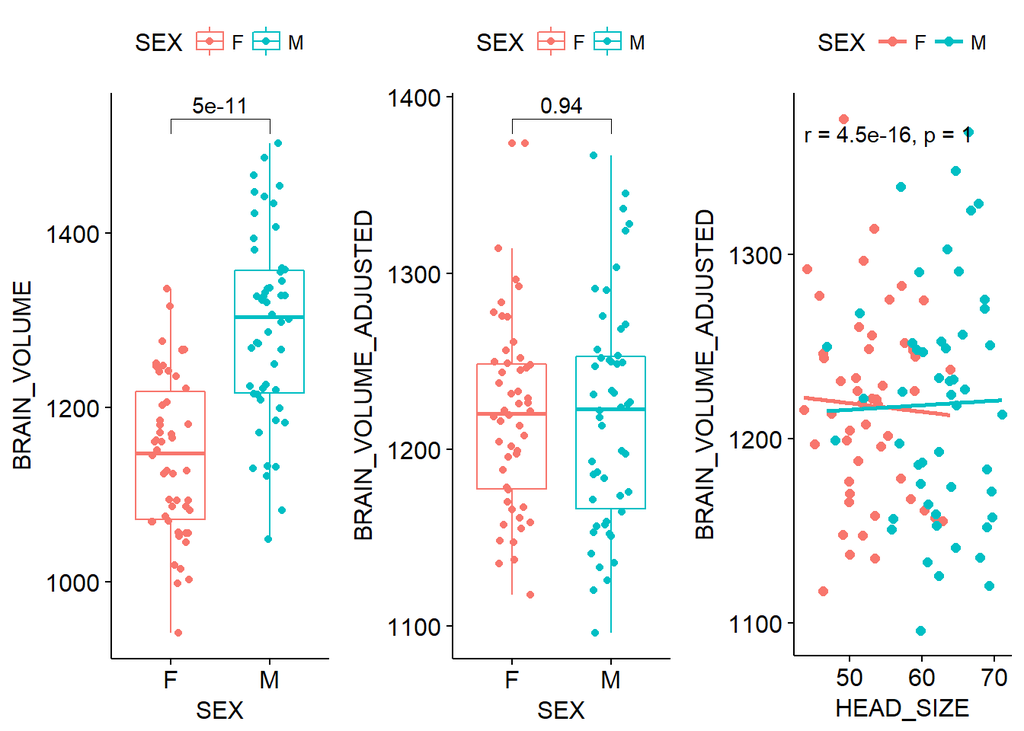

```r
# Regression analyis
head_size_fit <- lm(data = my_data, BRAIN_VOLUME ~ HEAD_SIZE)
my_data$BRAIN_VOLUME_ADJUSTED <- head_size_fit$residuals + mean(my_data$BRAIN_VOLUME)

# Comparison of original BRAIN_VOLUME and adjusted BRAIN_VOLUME_HEADSIZE_ADJ

# Plot SEX Difference in BRAIN_VOLUME
plot1 <- ggboxplot(data = my_data, x = "SEX",
                   y = "BRAIN_VOLUME", col = "SEX", add = "jitter") +
        stat_compare_means(method = "t.test",
                           comparisons = group_comparison_list,
                           aes(label = ..p.format..)
                           )
# Plot SEX Difference in BRAIN_VOLUME_ADJUSTED
plot2 <- ggboxplot(data = my_data, x = "SEX",
                   y = "BRAIN_VOLUME_ADJUSTED", col = "SEX", add = "jitter") +
        stat_compare_means(method = "t.test",
                           comparisons = group_comparison_list,
                           aes(label = ..p.format..)
                           )
# Plot HEAD_SIZE to BRAIN_VOLUME_ADJUSTED
plot3 <- ggscatter(data = my_data, x = "HEAD_SIZE",
                   y = "BRAIN_VOLUME_ADJUSTED", col = "SEX", add = "reg.line") +
        stat_cor()


ggarrange(plot1,plot2,plot3, nrow = 1, ncol = 3)
```

```r
rm(plot1,plot2,plot3)
```

# BRAIN_VOLUME AGE Association

It is known that during Age the brain volume will get small due to atrophy. Compare the association between AGE and BRAIN_VOLUME and AGE and BRAIN_VOLUME_ADJUSTED. You can appreciate how the correction for HEAD_SIZE helped to sharpen this association by removing variability of brain volume due to different head sizes.

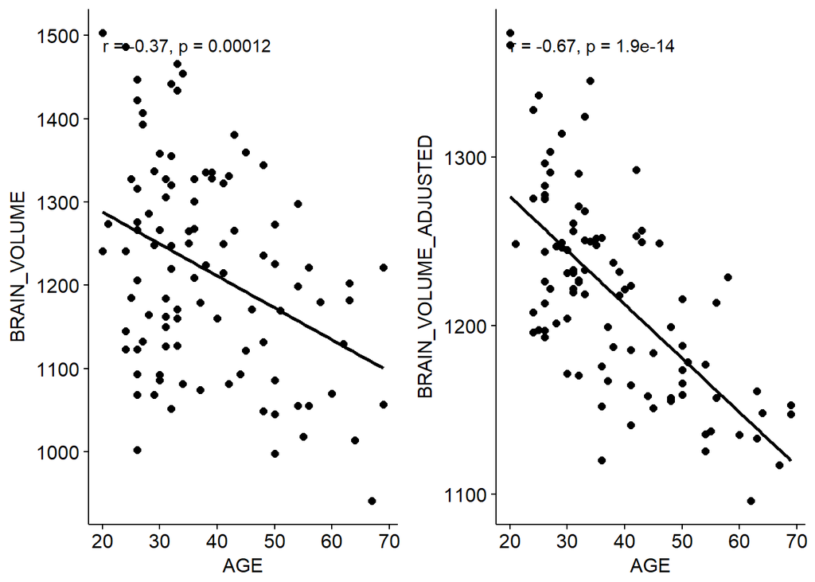

```r
# Plot BRAIN_VOLUME AGE Association
plot_age1 <- ggscatter(data = my_data, x = "AGE",
                   y = "BRAIN_VOLUME", add = "reg.line") +
        stat_cor()

# Plot BRAIN_VOLUME_ADJUSTED AGE Association
plot_age2 <- ggscatter(data = my_data, x = "AGE",
                   y = "BRAIN_VOLUME_ADJUSTED", add = "reg.line") +
        stat_cor()


ggarrange(plot_age1,plot_age2, nrow = 1, ncol = 2)
```